# MPDW 5

# Inisialisasi Library dan Import Dataset

```r
library(readxl)
library(ggplot2)
library(tsibble)
library(tseries)
library(MASS)
library(forecast)
library(TSA)
library(TTR)
library(aTSA)
library(graphics)
```

```r
data <- read_xlsx ("C:\\Users\\Lusi Oktaviani\\OneDrive\\Statistics and Data Science\\Semester 5\\MPDW\\Praktikum\\Data.xlsx")
```

# Eksplorasi Data

#### Plot Data Penuh

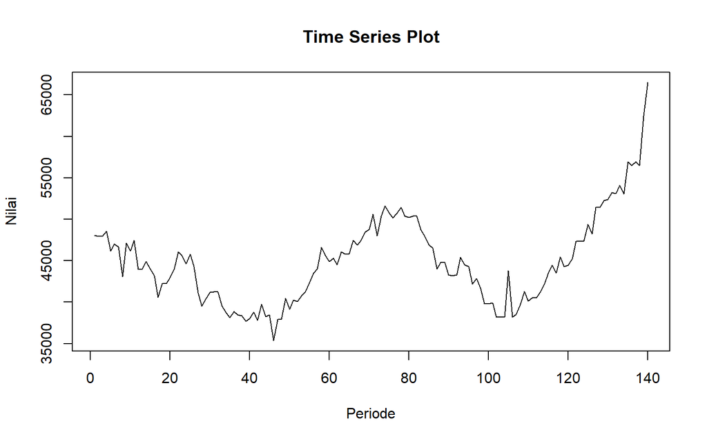

```r
data.ts <- ts(data$Nilai)
ts.plot(data.ts, xlab="Periode", ylab="Nilai", main="Time Series Plot")
```

# Split Data

```r
train <- data[1:118,]
test <- data[119:140,]
train.ts <- ts(train$Nilai)
test.ts <- ts(test$Nilai)
```

## Plot Data Latih

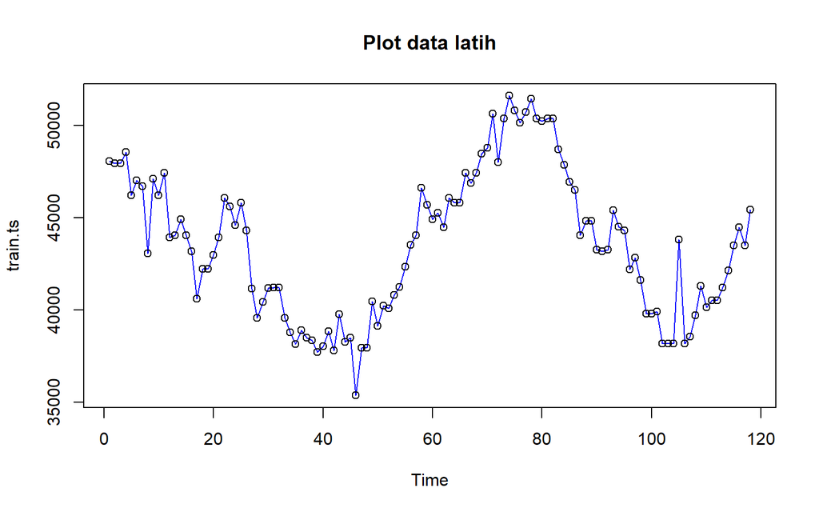

```r
plot(train.ts, col="blue",main="Plot data latih")
points(train.ts)
```

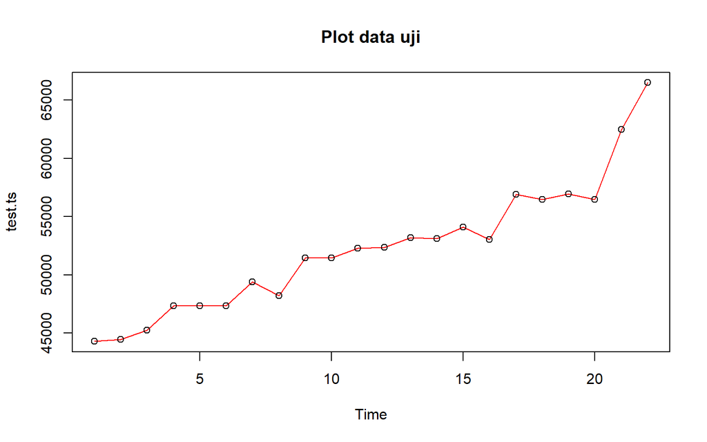

```r
plot(test.ts, col="red",main="Plot data uji")
points(test.ts)
```

# Identifikasi Stasioneritas Data

## Plot ACF

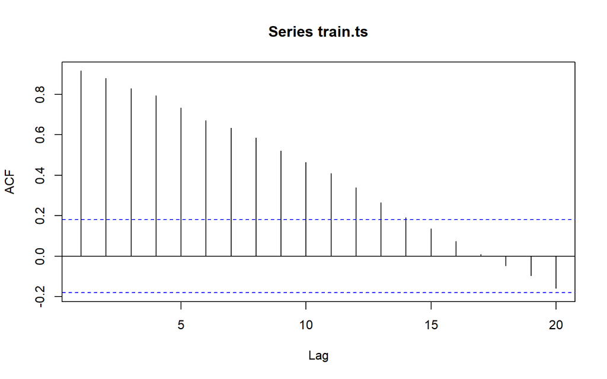

```r
acf(train.ts)
```

Berdasarkan plot ACF, terlihat bahwa plot ACF data menurun *tails off*.

## Uji ADF

```r
tseries::adf.test(train.ts)
```

```
##
##  Augmented Dickey-Fuller Test
##
## data:  train.ts
## Dickey-Fuller = -1.8347, Lag order = 4, p-value = 0.6452
## alternative hypothesis: stationary
```

$H_0$ : Data tidak stasioner dalam rataan

$H_1$ : Data stasioner dalam rataan

#### Plot Box-Cox

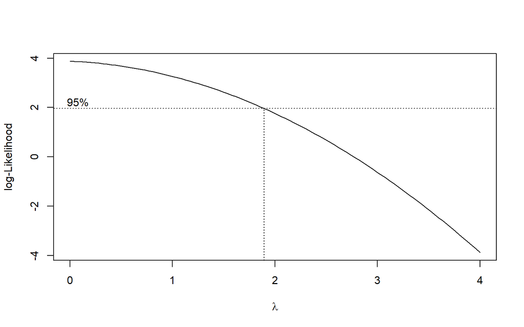

```r
index <- seq(1:118)
bc = boxcox(train.ts~index, lambda = seq(0,4,by=1))
```

```r
#Nilai Rounded Lambda
lambda <- bc$x[which.max(bc$y)]
lambda
```

```
## [1] 0
```

```r
#SK
bc$x[bc$y > max(bc$y) - 1/2 * qchisq(.95,1)]
```

```
##  [1] 0.00000000 0.04040404 0.08080808 0.12121212 0.16161616 0.20202020
##  [7] 0.24242424 0.28282828 0.32323232 0.36363636 0.40404040 0.44444444
## [13] 0.48484848 0.52525253 0.56565657 0.60606061 0.64646465 0.68686869
## [19] 0.72727273 0.76767677 0.80808081 0.84848485 0.88888889 0.92929293
## [25] 0.96969697 1.01010101 1.05050505 1.09090909 1.13131313 1.17171717
## [31] 1.21212121 1.25252525 1.29292929 1.33333333 1.37373737 1.41414141
## [37] 1.45454545 1.49494949 1.53535354 1.57575758 1.61616162 1.65656566
## [43] 1.69696970 1.73737374 1.77777778 1.81818182 1.85858586
```

Plot Boxcox menunjukkan nilai *rounded value* (𝜆) optimum sebesar **0** dan pada selang kepercayaan 95% nilai memiliki batas bawah **0** dan batas atas **1.85858**. Selang tersebut memuat nilai satu sehingga dapat dikatakan bahwa data stasioner dalam ragam.

### Penanganan Ketidakstasioneran Data

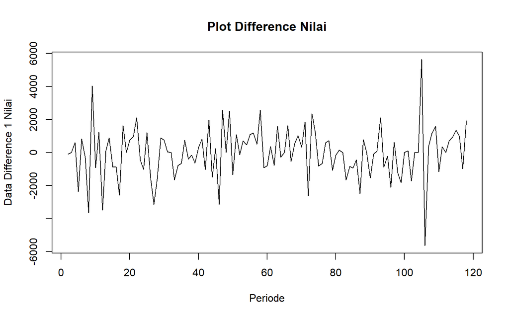

```r
train.diff<-diff(train.ts,differences = 1)
plot.ts(train.diff, lty=1, xlab="Periode", ylab="Data Difference 1 Nilai", main="Plot Difference Nilai")
```

Berdasarkan plot data deret waktu, terlihat bahwa data sudah stasioner dalam rataan ditandai dengan data bergerak pada nilai tengah tertentu (tidak terdapat trend ataupun musiman pada data)

#### Plot ACF

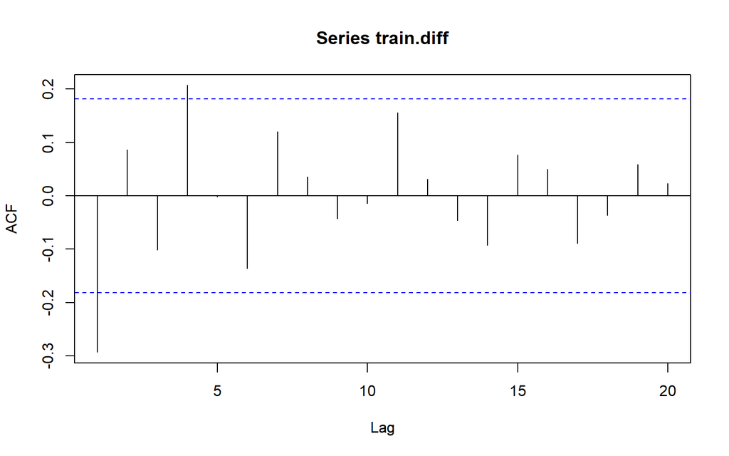

```r
acf(train.diff)
```

Berdasarkan plot tersebut, terlihat bahwa plot ACF cuts off pada lag ke 1. Hal ini menandakan data sudah stasioner dalam rataan dan ketidakstasioneran data telah berhasil tertangani.

#### Uji ADF

```r
tseries::adf.test(train.diff)
```

```
##
##  Augmented Dickey-Fuller Test
##
## data:  train.diff
## Dickey-Fuller = -3.8348, Lag order = 4, p-value = 0.0197
## alternative hypothesis: stationary
```

$H_0$ : Data tidak stasioner dalam rataan

$H_1$ : Data stasioner dalam rataan

Berdasarkan uji ADF tersebut, didapat *p-value* sebesar 0.0197 yang lebih kecil dari taraf nyata 5% sehingga tolak $H_0$ atau data stasioner dalam rataan. Hal ini sesuai dengan hasil eksplorasi menggunakan plot time series dan plot ACF, sehingga dalam hal ini ketidakstasioneran data sudah berhasil ditangani dan dapat dilanjutkan ke pemodelan

### Identifikasi Model

#### Plot ACF

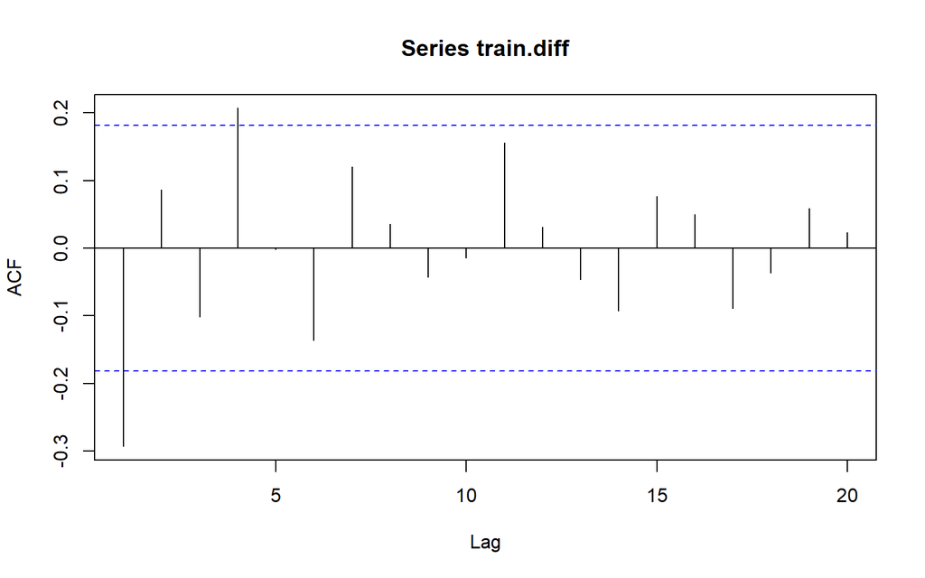

```r
acf(train.diff)
```

Berdasarkan plot tersebut, terlihat bahwa plot ACF cenderung *cuts off* pada lag ke 1, sehingga jika plot PACF dianggap *tails of*, maka model tentatifnya adalah ARIMA(0,1,1).

#### Plot PACF

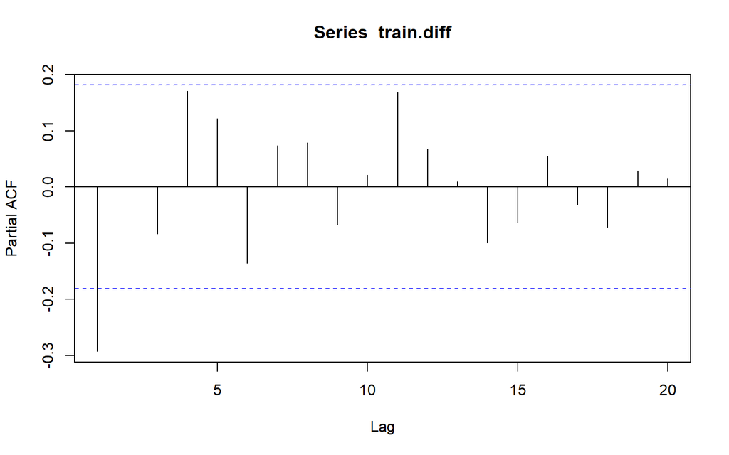

```r
pacf(train.diff)
```

Berdasarkan plot tersebut, terlihat bahwa plot PACF cenderung *cuts off* pada lag ke 1, sehingga jika plot ACF dianggap *tails of*, maka model tentatifnya adalah ARIMA(1,1,0).

Jika baik plot ACF maupun plot PACF keduanya dianggap tails of, maka model yang terbentuk adalah ARIMA(1,1,1)

#### Plot EACF

```r
eacf(train.diff)
```

```
## AR/MA
##   0 1 2 3 4 5 6 7 8 9 10 11 12 13
## 0 x o o x o o o o o o o  o  o  o
## 1 o o o x o o o o o o o  o  o  o
## 2 o o o o o o o o o o o  o  o  o
## 3 x o x x o o o o o o o  o  o  o
## 4 x x x x o o o o o o o  o  o  o
## 5 x o x x o o o o o o o  o  o  o
## 6 x x x o o o o o o o o  o  o  o
## 7 x x x o o o o o o o o  o  o  o
```

Identifikasi model menggunakan plot EACF dilakukan dengan melihat ujung segitiga pada pola segitiga nol. Dalam hal ini model tentatif yang terbentuk adalah ARIMA(0,1,4), ARIMA(1,1,4), ARIMA(2,1,3), ARIMA(3,1,4),dan ARIMA(4,1,4).